# MG205: Econometrics Theory and Applications

Topic 5: Functional Forms

José Ignacio González-Rojas

j.i.gonzalez-rojas@lse.ac.uk

London School of Economics and Political Science

## Reality Rarely Follows Straight Lines

### Linear Models Cannot Capture Every Economic Relationship

#### What We’ve Used So Far

$$y_i = \beta_0 + \beta_1 x_{i1} + \beta_2 x_{i2} + e_i$$

- **Constant effects**: One more unit of $x$ always changes $y$ by $\beta_1$
- **No interactions**: Effect of $x_1$ doesn’t depend on $x_2$
- **No curvature**: Relationship must be straight line

#### Real Economic Phenomena

- **Diminishing returns**: Training effective initially
- **Threshold effects**: Competition helps until it becomes destructive
- **Differential effects**: Age-earnings profile differs by gender
- **Structural breaks**: Productivity jumps after software adoption

Extend OLS to capture these patterns while preserving interpretability

## Two Types of Functional Form Extensions

### Each Addresses Different Economic Mechanisms

| Extension | Economic Question | Mathematical Form | Key Interpretation |
| --- | --- | --- | --- |
| **Polynomial terms** | Does marginal effect change? | $y = \beta_0 + \beta_1 x + \beta_2 x^2$ | $\frac{\partial y}{\partial x} = \beta_1 + 2\beta_2 x$ |
| **Interaction terms** | Does effect depend on another variable? | $$\begin{align*} y &= \beta_0 + \beta_1 x_1 + \beta_2 x_2 \\ &+ \beta_3(x_1 \times x_2) \end{align*}$$ | $\frac{\partial y}{\partial x_1} = \beta_1 + \beta_3 x_2$ |

We retain OLS estimation but interpretation changes fundamentally

# **Polynomial Terms:** Capturing Nonlinear Relationships

## **Exercise 1:** Training Shows Increasing Returns

### Quadratic Specification Reveals Convex Productivity Function

#### Experimental design

Company randomly assigned 5-25 hours of training to workers, then estimated:

$$\widehat{\text{productivity}}_i = 0.4 - 0.4 \cdot \text{hours}_i + 0.1 \cdot \text{hours}_i^2$$

#### Key questions

1. What is the marginal effect of one more training hour?
2. Are there economies or diseconomies of scale?
3. At what training level is the marginal effect highest?

## Marginal Effects in Quadratic Models Depend on $x$ Value

### Taking Partial Derivatives Reveals Non-Constant Returns

#### Marginal effect changes with training level

$$\begin{align*}
\frac{\partial \widehat{\text{productivity}}}{\partial \text{hours}} &= \frac{\partial}{\partial \text{hours}}(0.4 - 0.4 \cdot \text{hours} + 0.1 \cdot \text{hours}^2) \\
&= -0.4 + 2(0.1)\text{hours} \\
&= -0.4 + 0.2 \cdot \text{hours}
\end{align*}$$

#### Each additional hour becomes more valuable

- **At 5 hours**: $-0.4 + 0.2(5) = 0.6$ units per hour
- **At 10 hours**: $-0.4 + 0.2(10) = 1.6$ units per hour
- **At 25 hours**: $-0.4 + 0.2(25) = 4.6$ units per hour

## Convexity Implies Increasing Returns to Scale

### Second Derivative Determines Economies vs Diseconomies

#### Since second derivative is positive

$$\begin{align*}
\frac{\partial^2 \widehat{\text{productivity}}}{\partial \text{hours}^2} &= \frac{\partial}{\partial \text{hours}}(-0.4 + 0.2 \cdot \text{hours}) \\
&= 0.2 > 0
\end{align*}$$

- Function is **convex** (U-shaped)
- Marginal returns **increase** with training
- **Economies of scale** present

#### Should train workers maximally within feasible range $\in [5, 25]$ hours

- Marginal effect increasing throughout range
- Maximum at boundary: **25 hours**
- Value: $-0.4 + 0.2(25) = 4.6$ units/hour

## **Exercise 2:** Competition and Innovation Follow Inverted-U

### Concave Relationship Shows Optimal Intermediate Competition

#### Does competition monotonically increase innovation, or is there an optimal level?

$$\widehat{\text{innovation}}_i = 0.7 + 0.3 \cdot \text{competition}_i - 0.12 \cdot \text{competition}_i^2$$

where competition $\in [0,1]$ by construction

#### Questions to answer

1. What is marginal effect of competition?
2. Does regression suggest concave relation?
3. Where is marginal effect highest?
4. Is effect always positive?
5. Is effect always $\geq 0.2$?
6. Are fitted values always $> 1$?

## Marginal Effect of Competition Varies Across Its Range

### Derivative Shows Declining But Positive Impact

#### Marginal effect declines as competition increases

$$\begin{align*}
\frac{\partial \widehat{\text{innovation}}}{\partial \text{competition}} &= 0.3 - 2(0.12)\text{competition} \\
&= 0.3 - 0.24 \cdot \text{competition}
\end{align*}$$

#### Since second derivative is negative

$$\frac{\partial^2 \widehat{\text{innovation}}}{\partial \text{competition}^2} = -0.24 < 0$$

- Function is **concave** (inverted-U)
- Marginal returns **decrease** with competition
- Consistent with hypothesis

## Competition Has Strongest Effect When Low

### Boundary Analysis Reveals Effect Is Always Positive

#### (c) Maximum marginal effect $0.3 - 0.24 \cdot \text{competition}$

- **Decreasing** in competition
- Maximum at **competition = 0**
- Value: $0.3 - 0.24(0) = 0.3$

#### (d) Always positive marginal effect throughout $[0,1]$ range

$$0.3 - 0.24(1) = 0.06 > 0$$

#### (e) Marginal effect always $\geq 0.2$?

**No**, falls below 0.2 at high competition levels

#### (f) Fitted values do not exceed $> 1$

$$0.7 + 0.3(1) - 0.12(1)^2 = 0.88 < 1$$

Some competition beneficial, but effect weakens

## **Exercise 3:** Productivity Growth With Structural Break

### Quadratic Time Trend Plus Dummy Captures Software Adoption

#### The model

$$\widehat{\text{productivity}}_t = \underset{(2)}{4} + \underset{(0.05)}{0} \cdot \text{day}_t + \underset{(0.05)}{0.3} \cdot \text{day}_t^2 - \underset{(0.02)}{10} \cdot \mathbb{1}[t > 10]$$

where:

- $\text{day}_t \in \{0,1,2,\ldots,20\}$ is linear time variable
- $\mathbb{1}[t > 10]$ is indicator for the days after software adoption day

#### Create scatter plot consistent with this regression line

## Interpreting Each Component of the Productivity Model

### Four Terms Combine to Create Observed Pattern

#### Initial level: $\hat{\beta}_0 = 4$

- Productivity starts at 4 units on day 0
- Intercept (significant: $|4/2| = 2 > 1.96$)

#### Linear time trend: $\hat{\beta}_1 = 0$

- No linear component (not significant)
- Growth entirely from quadratic term

#### Quadratic trend: $\hat{\beta}_2 = 0.3$

- Convex growth ($0.3 > 0$)
- Marginal effect: $\frac{\partial \text{prod}}{\partial \text{day}} = 2(0.3)\text{day} = 0.6 \cdot \text{day}$
- Accelerating productivity gains

#### Structural break: $\hat{\beta}_3 = -10$

- Software adoption causes 10-unit drop
- Highly significant ($|-10/0.02| = 500$)
- Temporary disruption from learning curve

## The Resulting Pattern Shows Disruption Then Acceleration

### Visualisation Reveals U-Shaped Recovery

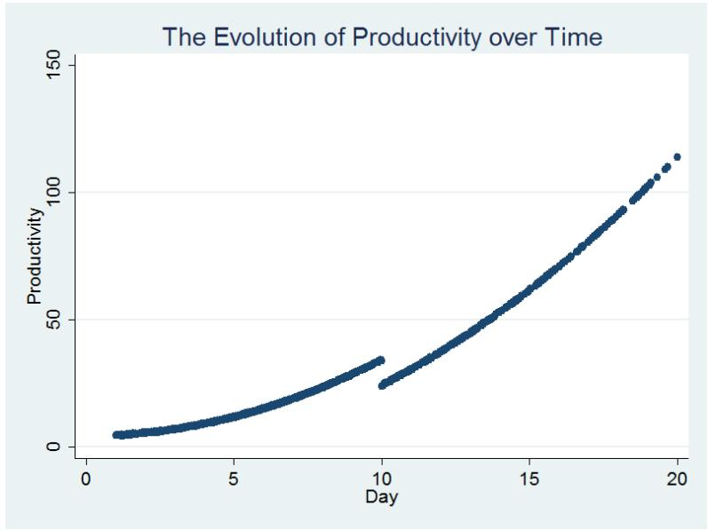

Evolution of Productivity Over Time

Quadratic captures learning, dummy captures disruption from change

## Mathematical Details of Productivity Function Details

### Complete Characterization of Turning Points and Growth Rates

#### Pre-software period ($t \leq 10$)

$$\widehat{\text{prod}}_t = 4 + 0.3t^2$$

**Marginal effect:** $0.6t$

- Day 5: $0.6(5) = 3$ units/day
- Day 10: $0.6(10) = 6$ units/day

#### Post-software period ($t > 10$)

$$\widehat{\text{prod}}_t = -6 + 0.3t^2$$

**Same marginal growth rate:** $0.6t$

- Parallel shifted down by 10 units
- Eventually exceeds pre-software level

**Break-even day:** Solve $-6 + 0.3t^2 = 4 + 0.3(10)^2$

# **Dummy Variable Precision:** Sample Composition Matters

## **Exercise 4:** Gender Wage Gap Estimated Most Precisely at 50-50 Split

### Balanced Sample Maximises Variation, Minimises Variance

#### The variance formula for dummy variables

$$\text{Var}(\hat{\beta}_1) = \frac{\sigma^2}{\sum_{i=1}^n(M_i - \bar{M})^2} = \frac{\sigma^2}{\frac{n_m \cdot n_f}{n}}$$

where $n_m$ = number males, $n_f$ = number females

#### Question

For fixed sample size $n$, what split minimises $\text{Var}(\hat{\beta}_1)$?

## Maximum Variance in $x$ Minimises Variance in $\hat{\beta}$

### Mathematical Optimisation Reveals 50-50 Split Is Optimal

#### Setting up the optimisation

$$\text{Var}(\hat{\beta}_1) = \frac{\sigma^2}{\frac{n_m \cdot n_f}{n}}$$

**To minimise variance:**

- Maximise $n_m \cdot n_f$ subject to $n_m + n_f = n$

#### Solving the constraint

- Let $n_m = p \cdot n$ and $n_f = (1-p) \cdot n$
- Maximise: $f(p) = p(1-p)n^2$
  $$\begin{align*}
  \frac{\partial f}{\partial p} &= n^2(1 - 2p) = 0 \\
  \implies p^* &= 0.5
  \end{align*}$$
- **Optimal split:** $n_m = n_f = 0.5n$

## **Exercise 5:** Unbalanced Variables Have Higher Coefficient Variance

### Comparing Female (50%) vs White (90%) Coefficient Precision

#### Population model with two uncorrelated dummies

$$\text{earnings}_i = \beta_0 + \beta_1 \cdot \mathbb{1}[i\text{ is female}] + \beta_2 \cdot \mathbb{1}[i\text{ is white}] + e_i$$

- 50% of population is **female**
- 90% of population is **white**
- **Correlation**: zero by assumption ($R^2_{\text{female}} = R^2_{\text{white}} = 0$)

#### Which coefficient has lower variance: $\hat{\beta}_{\text{female}}$ or $\hat{\beta}_{\text{white}}$?

## Balanced Variables Yield More Precise Estimates

### Variance Formula Shows Female Coefficient More Precise

$$\text{Var}(\hat{\beta}_{\text{category}}) = \frac{\sigma^2}{\sum_{i=1}^n(\mathbb{1}[i\text{ is category}] - \mathbb{P}[i\text{ is category}])^2}$$

(No $(1-R^2)$ term since uncorrelated)

#### Female takes values 0 and 1 with equal probability (See Exercise 4)

$$\begin{align*}
\sum_{i=1}^n(\mathbb{1}[i\text{ is female}] - 0.5)^2 &> \sum_{i=1}^n(\mathbb{1}[i\text{ is white}] - 0.9)^2
\end{align*}$$

$\therefore \text{Var}(\hat{\beta}_{\text{female}}) < \text{Var}(\hat{\beta}_{\text{white}})$

# **Interaction Terms:** When Effects Depend on Context

### Interaction Between Distance and Competition

#### Does competition affect airfares differently on short vs long routes?

$$\begin{align*}
\widehat{\log(\text{fare}_{i})} &= \underset{(0.14)}{2.85} - \underset{(0.30)}{0.43} \cdot \text{competition}_i + \underset{(0.02)}{0.36} \cdot \log(\text{distance}_{i}) \\
&+ \underset{(0.01)}{0.05} \cdot (\log(\text{distance}_{i}) \times \text{competition}_i)
\end{align*}$$

#### Questions

1. What is marginal effect of competition on $\log(\text{fare})$?
2. What is marginal effect of $\log(\text{distance})$ on $\log(\text{fare})$?
3. Test $H_0: \beta_{\text{competition}} = 0$. Does this imply competition has no effect?

## Marginal Effects Now Depend on Other Variables

### Taking Partial Derivatives With Interactions

#### (a) Marginal Effect of competition increases with distance

$$\begin{align*}
\frac{\partial \widehat{\log(\text{fare})}}{\partial \text{competition}} &= -0.43 \\
&+ 0.05 \cdot \log(\text{distance})
\end{align*}$$

- Short route $(\log(\text{distance}) = 5)$: $-0.43 + 0.05(5) = -0.18$
- Long route $(\log(\text{distance}) = 7)$: $-0.43 + 0.05(7) = -0.08$

#### (b) Marginal Effect of distance increases with competition

$$\begin{align*}
\frac{\partial \widehat{\log(\text{fare})}}{\partial \log(\text{distance})} &= 0.36 \\
&+ 0.05 \cdot \text{competition}
\end{align*}$$

- **Base elasticity:** 0.36 (when competition = 0)
- Each unit of competition adds 0.05 to elasticity

## Testing Individual Coefficients Can Be Misleading

### Never conclude “no effect” from insignificant main term when interaction present

**(c) Testing $H_0: \beta_{\text{comp}} = 0$**
$$t = \frac{-0.43 - 0}{0.30} = -1.43$$

- **Decision:** Fail to reject $H_0$ ($|-1.43| < 1.96$)
- **Does this mean competition has no effect on fares?**
  - **No!** This tests whether competition coefficient is zero **when** $\log(\text{distance})= 0$
  - The actual marginal effect is: $-0.43 + 0.05 \cdot \log(\text{distance})$

## **Exercise 9:** Gender-Specific Age-Earnings Profiles

### Derive Separate Functions for Males and Females

#### The estimated model

$$\begin{align*}
\widehat{\text{wage}}_i &= \underset{(1)}{-2} + \underset{(1)}{3} \cdot \mathbb{1}[i\text{ is female}] + \underset{(2)}{2} \cdot \text{age}_i + \underset{(1)}{8} \cdot (\mathbb{1}[i\text{ is male}] \times \text{age}_i) \\
&- \underset{(0.01)}{0.1} \cdot \text{age}_i^2 + \underset{(0.005)}{0.1} \cdot (\text{age}_i^2 \times \mathbb{1}[i\text{ is female}])
\end{align*}$$

- **Note:** $\mathbb{1}[i\text{ is male}] + \mathbb{1}[i\text{ is female}] = 1$ (mutually exclusive)

#### Task

Substitute gender indicator values to derive separate wage-age equations for each gender, then draw both functions.

## Deriving the Female Wage Function

### Substitute $\mathbb{1}[i\text{ is female}] = 1$, $\mathbb{1}[i\text{ is male}] = 0$

$$\begin{align*}
\widehat{\text{wage}}_i &= -2 + 3 \cdot \mathbb{1}[i\text{ is female}] + 2 \cdot \text{age}_i + 8 \cdot (\mathbb{1}[i\text{ is male}] \times \text{age}_i) \\
&- 0.1 \cdot \text{age}_i^2 + 0.1 \cdot (\text{age}_i^2 \times \mathbb{1}[i\text{ is female}]) \\
&= -2 + 3(1) + 2 \cdot \text{age}_i + 8(0 \times \text{age}_i) - 0.1 \cdot \text{age}_i^2 + 0.1(\text{age}_i^2 \times 1) \\
&= -2 + 3 + 2 \cdot \text{age}_i + 0 - 0.1 \cdot \text{age}_i^2 + 0.1 \cdot \text{age}_i^2 \\
&= 1 + 2 \cdot \text{age}_i
\end{align*}$$

## Deriving the Male Wage Function

### Substitute $\mathbb{1}[i\text{ is male}] = 1$, $\mathbb{1}[i\text{ is female}] = 0$

$$\begin{align*}
\widehat{\text{wage}}_i &= -2 + 3 \cdot \mathbb{1}[i\text{ is female}] + 2 \cdot \text{age}_i + 8 \cdot (\mathbb{1}[i\text{ is male}] \times \text{age}_i) \\
&\quad - 0.1 \cdot \text{age}_i^2 + 0.1 \cdot (\text{age}_i^2 \times \mathbb{1}[i\text{ is female}]) \\
&= -2 + 3(0) + 2 \cdot \text{age}_i + 8(1 \times \text{age}_i) - 0.1 \cdot \text{age}_i^2 + 0.1(\text{age}_i^2 \times 0) \\
&= -2 + 0 + 2 \cdot \text{age}_i + 8 \cdot \text{age}_i - 0.1 \cdot \text{age}_i^2 + 0 \\
&= -2 + 10 \cdot \text{age}_i - 0.1 \cdot \text{age}_i^2
\end{align*}$$

## Computing Slopes and Peak for Male Function

### Marginal effect and turning point

$$\frac{\partial \widehat{\text{wage}}}{\partial \text{age}}\bigg|_{\text{male}} = 10 - 0.2 \cdot \text{age}$$

### Peak wage age

$$\begin{align*}
10 - 0.2 \cdot \text{age} &= 0 \\
\text{age} &= 50
\end{align*}$$

### Concavity check

$$\frac{\partial^2 \widehat{\text{wage}}}{\partial \text{age}^2}\bigg|_{\text{male}} = -0.2 < 0$$

Function is concave (inverted-U shape)

## Visual Representation of Both Functions

### Female: Linear with Slope = 2, Male: Quadratic with Peak at Age 50

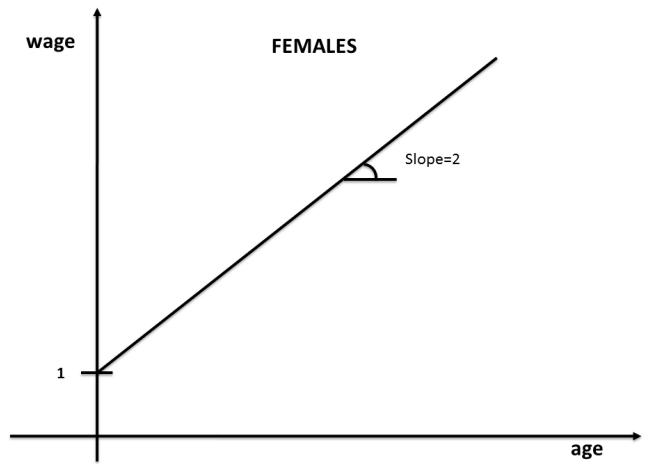

Female wage-age profile $\widehat{\text{wage}}_{i} = 1 + 2 \cdot \text{age}_{i}$

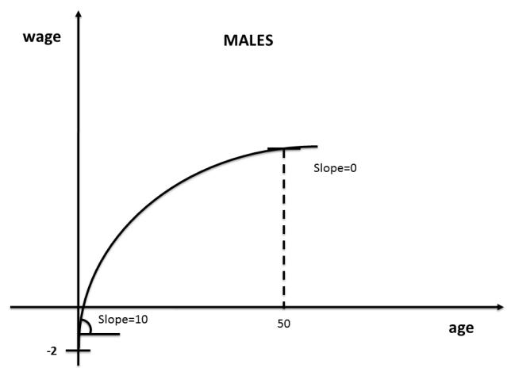

Male wage-age profile $\widehat{\text{wage}}_{i} = -2 + 10 \cdot \text{age}_{i} - 0.1 \cdot \text{age}_{i}^2$

## **Exercise 10:** Merger Effects Vary by Firm Characteristics

### Two Models Show How Interaction Terms Change Interpretation

#### Model 1: Main effects only

$$\begin{align*}
\widehat{\log(\text{patents}_{i})} &= \underset{(0.08)}{0.12} + \underset{(0.02)}{0.07} \cdot \log(\text{sales}_i) + \underset{(0.03)}{0.70} \cdot \log(\text{R\&D}_i) \\
&+ \underset{(0.15)}{0.97} \cdot \mathbb{1}[i\text{ has merger}] + \underset{(0.0005)}{0.0002} \cdot \text{employment}_i
\end{align*}$$

Based on 4,323 firms

## **Exercise 10:** Merger Effects Vary by Firm Characteristics

### Two Models Show How Interaction Terms Change Interpretation

#### Model 2: With interactions

$$\begin{align*}
\widehat{\log(\text{patents}_{i})} &= \underset{(0.08)}{0.16} + \underset{(0.02)}{0.06} \cdot \log(\text{sales}_i) + \underset{(0.03)}{0.72} \cdot \log(\text{R\&D}_i) \\
&- \underset{(0.98)}{2.39} \cdot \mathbb{1}[i\text{ has merger}] + \underset{(0.0005)}{0.0001} \cdot \text{employment}_i \\
&+ \underset{(0.15)}{0.55} \cdot (\mathbb{1}[i\text{ has merger}] \times \log(\text{sales}_i)) \\
&- \underset{(0.13)}{0.17} \cdot (\mathbb{1}[i\text{ has merger}] \times \log(\text{R\&D}_i))
\end{align*}$$

Based on 4,323 firms

## Interpreting Coefficients in Model 1 (No Interactions)

### Elasticities and Semi-Elasticities With Log-Level Specifications

#### (a) Three coefficient interpretations

**$\hat{\beta}_{\text{sales}} = 0.07$**

**Elasticity interpretation:**

- 1% increase in sales
- Associated with 0.07% increase in patents
- Log-log relationship

**$\hat{\beta}_{\text{employ}} = 0.0002$**

**$\hat{\beta}_{\text{merger}} = 0.97$**

**Semi-elasticity:**

- Merger (0→1)
- Patents increase 97%
- Nearly doubles innovation
- Substantial economic effect

## Expected Patent Levels Differ by Merger Status

### Conditional Expectations From Model 1

#### (b) Expected $\log(\text{patents}_{i})$ conditional on merger

**Firms with merger:**

$$\begin{align*}
\mathbb{E}[\log(\text{patents}_{i}) \mid \mathbb{1}[i\text{ has merger}] = 1] &= 0.12 + 0.07 \cdot \log(\text{sales}_{i}) \\
&+ 0.70 \cdot \log(\text{R\&D}_{i}) \\
&+ 0.97(1) \\
&+ 0.0002 \cdot \text{employment}_{i} \\
&= 1.09 + 0.07 \cdot \log(\text{sales}_{i}) \\
&+ 0.70 \cdot \log(\text{R\&D}_{i}) \\
&+ 0.0002 \cdot \text{employment}_{i}
\end{align*}$$

## Expected Patent Levels Differ by Merger Status

### Conditional Expectations From Model 1

#### (b) Expected $\log(\text{patents}_{i})$ conditional on merger

**Firms without merger:**

$$\begin{align*}
\mathbb{E}[\log(\text{patents}_{i}) \mid \mathbb{1}[i\text{ has merger}] = 0] &= 0.12 + 0.07 \cdot \log(\text{sales}_{i}) \\
&+ 0.70 \cdot \log(\text{R\&D}_{i}) \\
&+ 0.97(0) \\
&+ 0.0002 \cdot \text{employment}_{i}
\end{align*}$$

Merger shifts intercept up by 0.97 (log points) but slopes unchanged

## Testing Employment Effect Shows It’s Not Significant

### Standard t-Test on Level Variable in Log Specification

#### (c) Hypothesis test for $\beta_{\text{employment}}$

- **Setup:**
  - $H_0: \beta_{\text{employment}} = 0$
  - $H_1: \beta_{\text{employment}} \neq 0$ (two-sided)
- **Test statistic:** $t = \frac{0.0002 - 0}{0.0005} = 0.4$
- **Decision:** Fail to reject $H_0$ ($|0.4| < 1.96$)

Employment does not significantly predict innovation when controlling for sales and R&D

## Interactions Reveal Heterogeneous Merger Effects

### Model 2 Shows Merger Impact Depends on Firm Characteristics

#### (d) Partial effect of sales now depends on merger status

$$\frac{\partial \widehat{\log(\text{patents}_{i})}}{\partial \log(\text{sales}_{i})} = 0.06 + 0.55 \cdot \mathbb{1}[i\text{ has merger}]$$

**For merged firms $(\mathbb{1}[i\text{ has merger}] = 1):$**

$$\begin{align*}
\frac{\partial \widehat{\log(\text{patents}_{i})}}{\partial \log(\text{sales}_{i})} &= 0.06 + 0.55(1) \\
&= 0.61
\end{align*}$$

**For non-merged firms $(\mathbb{1}[i\text{ has merger}] = 0):$**

$$\begin{align*}
\frac{\partial \widehat{\log(\text{patents}_{i})}}{\partial \log(\text{sales}_{i})} &= 0.06 + 0.55(0) \\
&= 0.06
\end{align*}$$

Mergers amplify how sales translate into innovation output

## Sign Reversal on Merger Coefficient Explained by Interactions

### Never interpret main effect in isolation when interactions present

5. **Why did $\hat{\beta}_{\text{merger}}$ change from $+0.97$ to $-2.39$?**

**Model 1 measured average difference between merged and non-merged firms**

- $\hat{\beta}_{\text{merger}} = 0.97$

**Model 2 measures difference when $\log(\text{sales}_{i})$ and $\log(\text{R\&D}_{i}) = 0$:**

- $\hat{\beta}_{\text{merger}} = -2.39$
- This is an **extrapolation point** outside data range
- Not economically meaningful

## Expected Innovation Now Differs in Both Intercept and Slopes

### Conditional Expectations From Model 2

#### Merged firms $(\mathbb{1}[i\text{ has merger}] = 1)$

$$\begin{align*}
\mathbb{E}[\log(\text{patents}_{i}) \mid \mathbb{1}[i\text{ has merger}] = 1] &= 0.16 + 0.06 \cdot \log(\text{sales}_{i}) \\
&+ 0.72 \cdot \log(\text{R\&D}_{i}) \\
&- 2.39(1) + 0.0001 \cdot \text{employment}_{i} \\
&+ 0.55(\log(\text{sales}_{i}) \times 1) \\
&\quad - 0.17(\log(\text{R\&D}_{i}) \times 1) \\
&= -2.23 + 0.61 \cdot \log(\text{sales}_{i}) \\
&\quad + 0.55 \cdot \log(\text{R\&D}_{i}) \\
&\quad + 0.0001 \cdot \text{employment}_{i}
\end{align*}$$

## Expected Innovation Now Differs in Both Intercept and Slopes

### Conditional Expectations From Model 2

#### Non-merged firms $(\mathbb{1}[i\text{ has merger}] = 0)$

$$\begin{align*}
\mathbb{E}[\log(\text{patents}_{i}) \mid \mathbb{1}[i\text{ has merger}] = 0] &= 0.16 + 0.06 \cdot \log(\text{sales}_{i}) \\
&+ 0.72 \cdot \log(\text{R\&D}_{i}) \\
&+ 0.0001 \cdot \text{employment}_{i}
\end{align*}$$

Effect of merger depends on firm size and R&D intensity

## R&D Interaction Effect Is Not Statistically Significant

### Testing Whether R&D Slope Differs by Merger Status

#### (g) Does partial effect of $\log(\text{R\&D})$ depend on merger?

- **Hypothesis:**
  - $H_0: \beta_{(\text{merger} \times \log(\text{R\&D}_{i}))} = 0$
  - $H_1: \beta_{(\text{merger} \times \log(\text{R\&D}_{i}))} \neq 0$
- **Test statistic:** $t = \frac{-0.17 - 0}{0.13} = -1.31$
- **Decision:** Fail to reject $H_0$ ($|-1.31| < 1.96$)

Cannot confidently assert that R&D effectiveness differs between merged and non-merged firms

# **Testing With Multiple Restrictions**

## **Exercise 7:** Do Wage Determinants Differ by Gender?

### Testing Whether Separate Regressions Are Needed

#### Should we run separate wage regressions for men and women, or can we pool them?

**Variables:**

- `lwage`: Log of hourly wages
- `educ`: Years of education
- `exp`: Years of work experience
- `manager`: Equals 1 if in managerial position, 0 otherwise

**Dataset:** 779 employees (534 men, 245 women) from large organisation

## Two Modelling Strategies With Different Assumptions

### Pooled vs Separate Regressions

#### **Strategy 1:** Pooled regression

$$\begin{align*}
\log(\text{wage}_{i}) &= \beta_{0} + \beta_{1} \cdot \text{education}_{i} \\
&+ \beta_{2} \cdot \text{experience}_{i} \\
&+ \beta_{3} \cdot \mathbb{1}[i\text{ is manager}] + v_i
\end{align*}$$

- **Assumes:** All coefficients identical for men and women
- **Parameters:** 4 ($\beta_0, \beta_1, \beta_2, \beta_3$)
- **More efficient** if assumption holds

#### **Strategy 2:** Separate regressions

**Run two models:**

- One for men only
- One for women only
- **Allows:** Different intercepts and slopes by gender
- **Parameters:** 8 total (4 for each gender)
- **More flexible** but uses more degrees of freedom

## Unrestricted Model Nests Both Strategies

### Using Interactions to Test Whether Pooling Is Valid

$$\begin{align*}
\log(\text{wage}_i) &= \beta_0 + \beta_1 \cdot \text{education}_i + \beta_2 \cdot \text{experience}_i + \beta_3 \cdot \text{manager}_i \\
&+ \beta_4 \cdot \mathbb{1}[i\text{ is female}] \\
&+ \beta_5 \cdot (\mathbb{1}[i\text{ is female}] \times \text{education}_i) \\
&+ \beta_6 \cdot (\mathbb{1}[i\text{ is female}] \times \text{experience}_i) \\
&+ \beta_7 \cdot (\mathbb{1}[i\text{ is female}] \times \text{manager}_i) + e_i
\end{align*}$$

## Gender-Specific Equations Derived by Substitution

### Setting Indicator to 0 or 1 Recovers Separate Regressions

#### Men ($\mathbb{1}[i\text{ is female}] = 0$)

$$\begin{align*}
\log(\text{wage}_i) &= \beta_0 + \beta_1 \cdot \text{education}_i \\
&+ \beta_2 \cdot \text{experience}_i \\
&+ \beta_3 \cdot \mathbb{1}[i\text{ is manager}] + e_i
\end{align*}$$

#### Women ($\mathbb{1}[i\text{ is female}] = 1$)

$$\begin{align*}
\log(\text{wage}_i) &= (\beta_0 + \beta_4) \\
&+ (\beta_1 + \beta_5) \cdot \text{education}_i \\
&+ (\beta_2 + \beta_6) \cdot \text{experience}_i \\
&+ (\beta_3 + \beta_7) \cdot \mathbb{1}[i\text{ is manager}] \\
&+ e_i
\end{align*}$$

Each gender has its own intercept and slopes in unrestricted model

## F-Test Required to Test Four Restrictions Jointly

### Cannot Use Four Individual t-Tests

#### Null hypothesis: Gender doesn’t affect any coefficient

$$H_0: \beta_4 = 0; \; \beta_5 = 0; \; \beta_6 = 0; \; \beta_7 = 0$$

- **Alternative:** At least one $\beta_j \neq 0$ for $j \in \{4,5,6,7\}$

#### Why not use four t-tests?

- Each test at $\alpha = 0.05$ level
- Probability of Type I error across all tests: $1 - (1-0.05)^4 = 0.185$
- Joint significance level inflates to 18.5%, not 5%

Must test all four restrictions simultaneously using F-test

## Computing the F-Statistic From Both Models

### Compare Sum of Squared Residuals

#### F-test procedure

$$F = \frac{(\text{SSR}_r - \text{SSR}_{ur})/q}{\text{SSR}_{ur}/(n-k-1)}$$

#### Distribution under null

$$F \sim F_{4, 771}$$

## Decision Rule Based on Critical Value

### Reject Null If F-Statistic Exceeds Threshold

#### Critical value at $\alpha = 0.05$

$$F_{4,771,0.05} = 2.37$$

#### If $F > 2.37$

- **Reject $H_0$**
- Gender affects at least one coefficient
- **Run separate regressions** for men and women
- Pooling imposes invalid restrictions

#### If $F \leq 2.37$

- **Fail to reject $H_0$**
- No evidence gender affects coefficients
- **Use pooled regression**
- More efficient estimation
- Gain precision from larger sample

## **Exercise 8:** Testing University Effects on Wages

### Three Universities, Three Pairwise Comparisons Required

#### Compare wage outcomes for graduates from:

- Cambridge (baseline/omitted category)
- LSE
- Oxford

**Want to test:**

1. LSE $\neq$ Cambridge?
2. Oxford $\neq$ Cambridge?
3. LSE $\neq$ Oxford?

#### How would we set up these tests using dummy variables and t-tests?

## Model 1: Testing Against Baseline Category

### Individual t-Tests for Each University vs Cambridge

$$\log(\text{wage}_i) = \alpha + \beta_{\text{LSE}} \cdot \mathbb{1}[i\text{ from LSE}] + \beta_{\text{OX}} \cdot \mathbb{1}[i\text{ from Oxford}] + e_i$$

where Cambridge is baseline (both dummies = 0)

#### Test 1: LSE vs Cambridge

- $H_0: \beta_{\text{LSE}} = 0$
- Use t-test on $\hat{\beta}_{\text{LSE}}$
- If reject: LSE earns differently from Cambridge

#### Test 2: Oxford vs Cambridge

- $H_0: \beta_{\text{OX}} = 0$
- Use t-test on $\hat{\beta}_{\text{OX}}$
- If reject: Oxford earns differently from Cambridge

## Comparing Non-Baseline Categories Requires Different Test

### LSE vs Oxford Cannot Be Tested With Single t-Statistic

#### Test 3: LSE vs Oxford

- **Hypothesis:** $H_0: \beta_{\text{LSE}} = \beta_{\text{OX}}$
- **Cannot use simple t-test because:**
  - This tests equality of two parameters
  - Not whether single parameter equals zero

## Comparing Non-Baseline Categories Requires Different Test

### LSE vs Oxford Cannot Be Tested With Single t-Statistic

#### Test 3: LSE vs Oxford

**Solution: F-test**

Compare:

- **Unrestricted model:** $\log(\text{wage}_i) = \alpha + \beta_{\text{LSE}} \cdot \mathbb{1}[i\text{ from LSE}] + \beta_{\text{OX}} \cdot \mathbb{1}[i\text{ from Oxford}] + e_i$
- **Restricted model:** $\log(\text{wage}_i) = \alpha + \beta \cdot (\mathbb{1}[i\text{ from LSE}] + \mathbb{1}[i\text{ from Oxford}]) + e_i$

Imposing constraint makes LSE and Oxford have same coefficient

## Testing Whether All Universities Have Same Wage-Experience Profile

### Model 2 Adds Experience and Interactions

$$\begin{align*}
\log(\text{wage}_{i}) &= \alpha + \beta_{\text{LSE}} \cdot \mathbb{1}[i\text{ from LSE}] + \beta_{\text{Oxford}} \cdot \mathbb{1}[i\text{ from Oxford}] \\
&+ \gamma \cdot \text{experience}_i + \gamma_{\text{LSE}} \cdot (\text{experience}_i \times \mathbb{1}[i\text{ from LSE}]) \\
&+ \gamma_{\text{OX}} \cdot (\text{experience}_i \times \mathbb{1}[i\text{ from Oxford}]) + e_i
\end{align*}$$

#### What this allows

- Different intercepts by university
- Different slopes w.r.t. experience by university

#### Alternative interpretation

- Three separate regressions (one per university)
- Model 2 estimates all simultaneously

## Joint Null Requires F-Test With Four Restrictions

### Testing All Differences Simultaneously

#### Null hypothesis: Single wage-experience profile

$$H_0: \beta_{\text{LSE}} = 0; \; \gamma_{\text{LSE}} = 0; \; \beta_{\text{OX}} = 0; \; \gamma_{\text{OX}} = 0$$

- **Restricted model:** $\log(\text{wage}_i) = \alpha + \gamma \cdot \text{EXP}_i + v_i$
- **F-test procedure:** $F = \frac{(\text{SSR}_r - \text{SSR}_{ur})/4}{\text{SSR}_{ur}/(n-5-1)} \sim F_{4, n-6}$
- Compare to critical value $c$ at chosen significance level
- Reject $H_0$ if $F > c$

Cannot test four restrictions jointly using individual $t$-tests

# Summary and Key Takeaways

## Four Critical Lessons About Functional Forms

### What We’ve Learned Today

#### 1. Polynomial terms capture nonlinearity

- Marginal effects vary with $x$ value
- Second derivative determines convexity/concavity

#### 2. Dummy variable precision depends on sample split

- Balanced samples decrease variance
- 50-50 split optimal for binary variables

#### 3. Interactions allow effects to depend on context

- Marginal effect of $x_1$ varies with $x_2$ value
- Cannot test “no effect” using only main coefficient

#### 4. Multiple hypotheses require F-tests

- Single t-tests insufficient for comparing categories
- Joint restrictions need simultaneous testing
- Interaction models change hypothesis test structure

## Next Week: Limitations of OLS

### When Our Standard Assumptions Break Down

**What we’ll cover:**

- **Omitted variable bias:** Confounders we cannot measure
- **Measurement error:** When variables measured with noise
- **Reverse causality:** Does beauty cause wages or vice versa?
- **Heteroskedasticity:** Non-constant error variance
- **Sample selection bias:** Non-random sampling problems

**Why it matters:**

- Real data violates assumptions systematically
- Need to diagnose problems and adjust methods
- Understanding limitations crucial for credible inference

# **Appendix:** Detailed Derivations

## **Exercise 3:** Productivity Model Complete Specification

### Pre-software period ($t \leq 10$)

$$\begin{align*}
\widehat{\text{productivity}}_t &= 4 + 0.3t^2 \\
\text{Marginal effect:} \quad \frac{d\text{prod}}{dt} &= 0.6t \\
\text{At } t = 0: &\quad \text{prod} = 4, \; \text{slope} = 0 \\
\text{At } t = 5: &\quad \text{prod} = 11.5, \; \text{slope} = 3 \\
\text{At } t = 10: &\quad \text{prod} = 34, \; \text{slope} = 6
\end{align*}$$

## Productivity Model Complete Specification (continued)

### After software adoption ($t > 10$)

#### Post-software period analysis

$$\begin{align*}
\widehat{\text{productivity}}_t &= 4 + 0.3t^2 - 10 = -6 + 0.3t^2 \\
\text{Marginal effect:} \quad \frac{d\text{prod}}{dt} &= 0.6t \text{ (unchanged)} \\
\text{At } t = 11: &\quad \text{prod} = 30.3, \; \text{slope} = 6.6 \\
\text{At } t = 15: &\quad \text{prod} = 61.5, \; \text{slope} = 9 \\
\text{At } t = 20: &\quad \text{prod} = 114, \; \text{slope} = 12
\end{align*}$$

## Productivity Model Complete Specification (continued)

### Finding break-even point

When does post-software productivity exceed pre-software trend?

$$\begin{align*}
-6 + 0.3t^2 &> 34 \\
0.3t^2 &> 40 \\
t^2 &> 133.33 \\
t &> 11.55
\end{align*}$$

Software pays off after day 12

Return to main